# Social Networks Project

Natalie Samuels

# Exploring the antecedents and utility of self-disclosure in college freshmen.

## Abstract

Adjusting to college is at once an exciting and stress-inducing process. One potentially helpful action students can take under stress is to disclose negative feelings to peers, thus enabling interpersonal emotion regulation and social support. However, students vary in their tendency to disclose negative feelings. Through trait data, social network nominations, and experience-sampling data, we explore trait and situational factors that influence students’ likelihood of disclosing stressful events to dorm-mates. For ten days throughout their first quarter on campus, students reported up to three daily stressors, along with the emotional intensity and category for each, and to whom, if anyone, each stressor was disclosed. Academic stressors were most likely to be disclosed and social stressors least likely. Additionally, stressors higher in emotional intensity were more likely to be disclosed. Whereas students experiencing more depression, anxiety, and perceived stress were equally as likely as their peers to disclose negative events, students experiencing greater feelings of loneliness were significantly less likely to engage in self-disclosure. Interestingly, self-disclosure was not found to influence daily changes in mood, affect, or stress. Future research will aim to assess the utility of disclosure over longer timescales. Findings from this exploratory analysis can help inform whether self-disclosure should be encouraged as a potential avenue to buffering stress and improving well-being during the transition to college.

## What types of stress do students experience?

```
## # A tibble: 1 x 3
##   mean_stressors sd_stressors count_stressors
##            <dbl>        <dbl>           <int>
## 1           11.7         7.65            1088
```

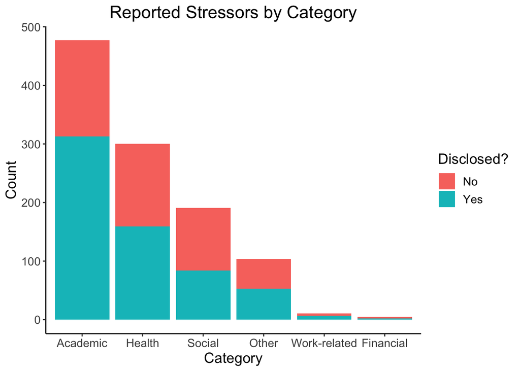

## How emotionally intense are the stressors students experience?

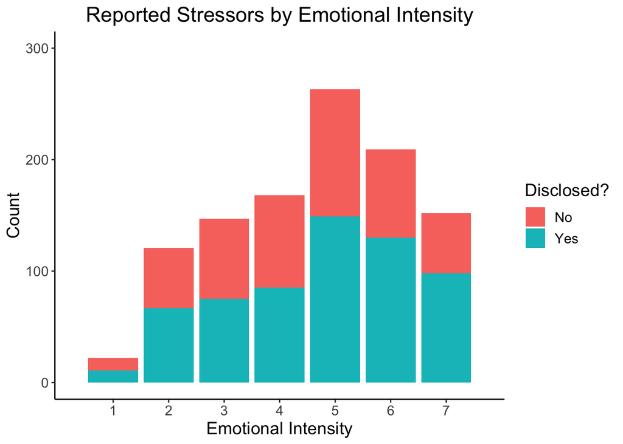

## How does the emotional intensity of reported stressors vary by category?

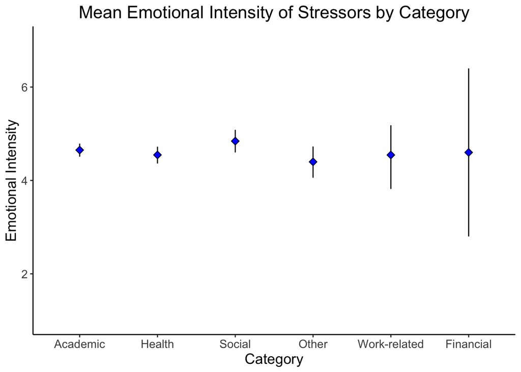

Emotional intensity of reported stressors does not vary significantly by category.

## How does the quality of a stressor influence students’ likelihood of disclosure?

```
## # A tibble: 16 x 8
##    term      estimate std.error statistic  p.value conf.low conf.high group
##    <chr>        <dbl>     <dbl>     <dbl>    <dbl>    <dbl>     <dbl> <chr>
##  1 (Interce…    0.811     0.202     4.01   6.19e-5    0.414    1.21   fixed
##  2 EmoRatin…    0.544     0.137     3.96   7.57e-5    0.274    0.813  fixed
##  3 Cat_Soc_…   -1.39      0.244    -5.71   1.12e-8   -1.87    -0.916  fixed
##  4 Cat_Heal…   -0.716     0.201    -3.55   3.78e-4   -1.11    -0.321  fixed
##  5 Cat_Fin     -1.13      1.24     -0.908  3.64e-1   -3.56     1.31   fixed
##  6 Cat_Job      1.54      3.96      0.389  6.97e-1   -6.23     9.31   fixed
##  7 Cat_Other   -0.704     0.323    -2.18   2.93e-2   -1.34    -0.0708 fixed
##  8 EmoRatin…   -0.285     0.240    -1.19   2.35e-1   -0.754    0.185  fixed
##  9 EmoRatin…   -0.171     0.200    -0.852  3.94e-1   -0.563    0.222  fixed
## 10 EmoRatin…   -0.184     1.01     -0.182  8.55e-1   -2.16     1.79   fixed
## 11 EmoRatin…   -2.03      1.03     -1.97   4.88e-2   -4.05    -0.0103 fixed
## 12 EmoRatin…   -0.754     0.305    -2.48   1.33e-2   -1.35    -0.157  fixed
## 13 sd_(Inte…    0.621    NA        NA     NA         NA       NA      Day.…
## 14 sd_Cat_O…    0.641    NA        NA     NA         NA       NA      ID
## 15 sd_(Inte…    1.37     NA        NA     NA         NA       NA      ID.1
## 16 sd_Cat_J…    3.70     NA        NA     NA         NA       NA      Dorm
```

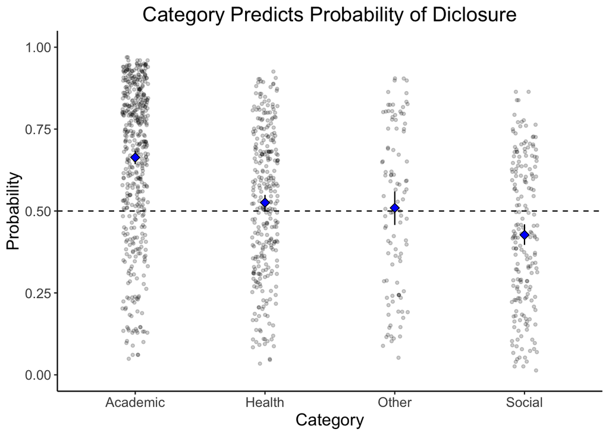

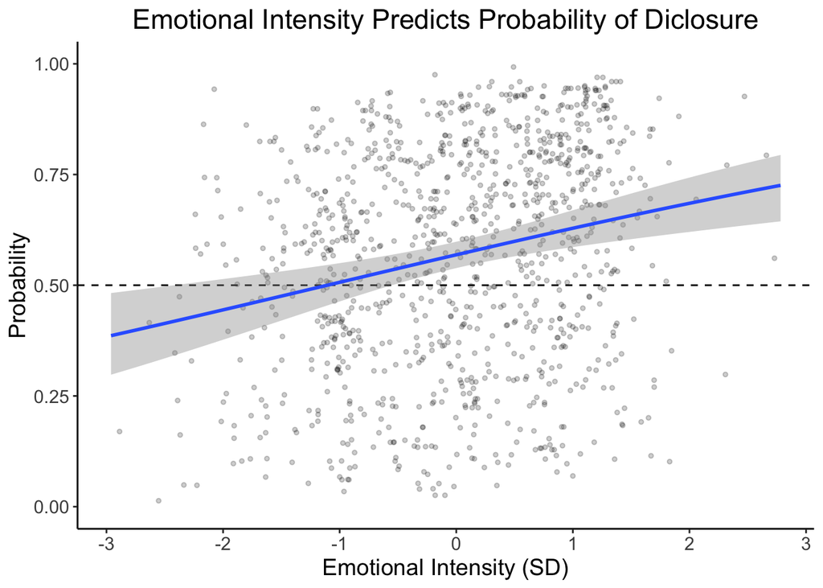

Students are most likely to disclose academic stressors to their peers and are slightly more likely than chance to disclose health-related stressors. Interestingly, students are slightly less likely than chance to disclose social stressors. Students are also more likely to disclose stressors that are higher in emotional intensity.

## How do students’ individual differences influence their likelihood of disclosure?

```
## # A tibble: 7 x 8
##   term       estimate std.error statistic  p.value conf.low conf.high group
##   <chr>         <dbl>     <dbl>     <dbl>    <dbl>    <dbl>     <dbl> <chr>
## 1 (Intercep…   0.402     0.148      2.72   6.58e-3    0.112     0.691 fixed
## 2 EmoRating…   0.287     0.0745     3.85   1.18e-4    0.141     0.433 fixed
## 3 Lonelines…  -1.09      0.431     -2.52   1.16e-2   -1.93     -0.243 fixed
## 4 CloseFrd_…   0.0730    0.0965     0.756  4.49e-1   -0.116     0.262 fixed
## 5 EmoRating…   0.0241    0.200      0.120  9.04e-1   -0.368     0.416 fixed
## 6 Lonelines…   0.140     0.213      0.656  5.12e-1   -0.277     0.557 fixed
## 7 sd_(Inter…   1.09     NA         NA     NA         NA        NA     ID
```

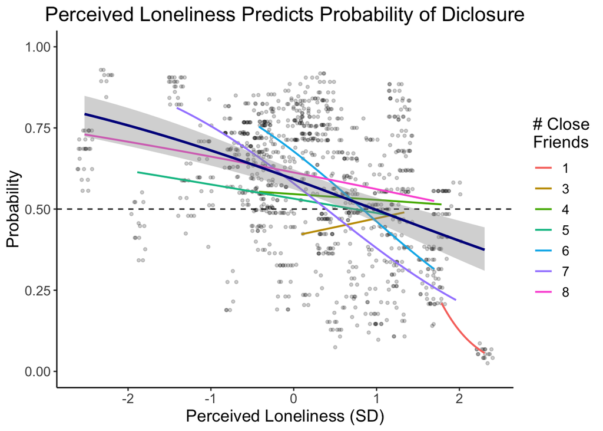

Students who experience more loneliness are less likely than their peers to disclose stressful events, regardless of the objective number of friendships the student reports having. Trait anxiety, depression, and perceived stress were also tested in separate models, but none emerged as significant predictors of disclosure.

## How do students’ social relationships influence their likelihood of disclosure?

Attributes of students’ social networks were used to predict their likelihood of disclosure. Neither the number of empathic friends nor the number responsive friends a student reported having in their dorm predicted significant differences in likelihood of disclosure.

## What is the utility of disclosing negative events to dorm-mates?

Students’ daily disclosure activity was used to predict satisfaction, loneliness, positive and negative affect, and stress the following day. Disclosing stress to a dorm-mate did not predict significant changes in these measures of well-being at the daily level.

## Next Steps

- How does disclosure influence wellbeing over longer timescales (quarter, year, etc.)?
- Do qualities of the support provider, such as empathy, influence the utility of disclosing negative events?
- Why do lonely students disclose their stress less frequently?
  - How do they benefit from disclosure vs. their less lonely peers?
  - How do they perceive the impact of their disclosure on the support provider?
  - How does their IRQ-E compare to their less lonely peers?
- To what extent does IRQ-E operate as a self-fulfilling mindset?